# Analysis of Prosper Loan Data

## by Temitope Bimbo Babatola

## Introduction

Prosper is a loan company. Featuring fixed interest online loans and credit cards with next-day approval and flexible terms. This data set contains 113,937 loans with 81 variables on each loan, including loan amount, borrower rate (or interest rate), current loan status, borrower income, and many others.

## Objective

My main objective is to understand the parameters that determine how prosperratings are assigned to loan applications.

## Preliminary Wrangling

### Data Dictionary

```python
# import all packages and set plots to be embedded inline
import numpy as np
import pandas as pd
import matplotlib.pyplot as plt
import seaborn as sns

%matplotlib inline
```

```python
import warnings
warnings.filterwarnings('ignore')
```

```python
pd.set_option('display.max_rows', 500)
pd.set_option('display.max_columns', 500)
```

```python
loan_data = pd.read_csv('prosperLoanData.csv')
loan_data.head()
```

|  | ListingKey | ListingNumber | ListingCreationDate | CreditGrade | Term | LoanStatus | ClosedDate | BorrowerAPR | BorrowerRate | LenderYield | EstimatedEffectiveYield | EstimatedLoss | EstimatedReturn | ProsperRating (numeric) | ProsperRating (Alpha) | ProsperScore | ListingCategory (numeric) | BorrowerState | Occupation | EmploymentStatus | EmploymentStatusDuration | IsBorrowerHomeowner | CurrentlyInGroup | GroupKey | DateCreditPulled | CreditScoreRangeLower | CreditScoreRangeUpper | FirstRecordedCreditLine | CurrentCreditLines | … |
| --- | --- | --- | --- | --- | --- | --- | --- | --- | --- | --- | --- | --- | --- | --- | --- | --- | --- | --- | --- | --- | --- | --- | --- | --- | --- | --- | --- | --- | --- | --- |
| 0 | 1021339766868145413AB3B | 193129 | 2007-08-26 19:09:29.263000000 | C | 36 | Completed | 2009-08-14 00:00:00 | 0.16516 | 0.1580 | 0.1380 | NaN | NaN | NaN | NaN | NaN | NaN | 0 | CO | Other | Self-employed | 2.0 | True | True | NaN | 2007-08-26 18:41:46.780000000 | 640.0 | 659.0 | 2001-10-11 00:00:00 | 5.0 | … |
| 1 | 10273602499503308B223C1 | 1209647 | 2014-02-27 08:28:07.900000000 | NaN | 36 | Current | NaN | 0.12016 | 0.0920 | 0.0820 | 0.07960 | 0.0249 | 0.05470 | 6.0 | A | 7.0 | 2 | CO | Professional | Employed | 44.0 | False | False | NaN | 2014-02-27 08:28:14 | 680.0 | 699.0 | 1996-03-18 00:00:00 | 14.0 | … |
| 2 | 0EE9337825851032864889A | 81716 | 2007-01-05 15:00:47.090000000 | HR | 36 | Completed | 2009-12-17 00:00:00 | 0.28269 | 0.2750 | 0.2400 | NaN | NaN | NaN | NaN | NaN | NaN | 0 | GA | Other | Not available | NaN | False | True | 783C3371218786870A73D20 | 2007-01-02 14:09:10.060000000 | 480.0 | 499.0 | 2002-07-27 00:00:00 | NaN | … |
| 3 | 0EF5356002482715299901A | 658116 | 2012-10-22 11:02:35.010000000 | NaN | 36 | Current | NaN | 0.12528 | 0.0974 | 0.0874 | 0.08490 | 0.0249 | 0.06000 | 6.0 | A | 9.0 | 16 | GA | Skilled Labor | Employed | 113.0 | True | False | NaN | 2012-10-22 11:02:32 | 800.0 | 819.0 | 1983-02-28 00:00:00 | 5.0 | … |
| 4 | 0F023589499656230C5E3E2 | 909464 | 2013-09-14 18:38:39.097000000 | NaN | 36 | Current | NaN | 0.24614 | 0.2085 | 0.1985 | 0.18316 | 0.0925 | 0.09066 | 3.0 | D | 4.0 | 2 | MN | Executive | Employed | 44.0 | True | False | NaN | 2013-09-14 18:38:44 | 680.0 | 699.0 | 2004-02-20 00:00:00 | 19.0 | … |

### Data Structure

```python
print(f"""The dataset has:
            {loan_data.shape[0]} rows
            {loan_data.shape[1]} columns
       """)
```

```
The dataset has:
            113937 rows
            81 columns
```

```python
loan_data.info()
```

```
<class 'pandas.core.frame.DataFrame'>
RangeIndex: 113937 entries, 0 to 113936
Data columns (total 81 columns):
 #   Column                               Non-Null Count   Dtype
---  ------                               --------------   -----
 0   ListingKey                           113937 non-null  object
 1   ListingNumber                        113937 non-null  int64
 2   ListingCreationDate                  113937 non-null  object
 3   CreditGrade                          28953 non-null   object
 4   Term                                 113937 non-null  int64
 5   LoanStatus                           113937 non-null  object
 6   ClosedDate                           55089 non-null   object
 7   BorrowerAPR                          113912 non-null  float64
 8   BorrowerRate                         113937 non-null  float64
 9   LenderYield                          113937 non-null  float64
```

[output cut: 73 more lines]

```python
loan_data.describe()
```

|  | ListingNumber | Term | BorrowerAPR | BorrowerRate | LenderYield | EstimatedEffectiveYield | EstimatedLoss | EstimatedReturn | ProsperRating (numeric) | ProsperScore | ListingCategory (numeric) | EmploymentStatusDuration | CreditScoreRangeLower | CreditScoreRangeUpper | CurrentCreditLines | OpenCreditLines | TotalCreditLinespast7years | OpenRevolvingAccounts | OpenRevolvingMonthlyPayment | InquiriesLast6Months | TotalInquiries | CurrentDelinquencies | AmountDelinquent | DelinquenciesLast7Years | PublicRecordsLast10Years | PublicRecordsLast12Months | RevolvingCreditBalance | BankcardUtilization | AvailableBankcardCredit | … |
| --- | --- | --- | --- | --- | --- | --- | --- | --- | --- | --- | --- | --- | --- | --- | --- | --- | --- | --- | --- | --- | --- | --- | --- | --- | --- | --- | --- | --- | --- | --- |
| count | 1.139370e+05 | 113937.000000 | 113912.000000 | 113937.000000 | 113937.000000 | 84853.000000 | 84853.000000 | 84853.000000 | 84853.000000 | 84853.000000 | 113937.000000 | 106312.000000 | 113346.000000 | 113346.000000 | 106333.000000 | 106333.000000 | 113240.000000 | 113937.00000 | 113937.000000 | 113240.000000 | 112778.000000 | 113240.000000 | 106315.000000 | 112947.000000 | 113240.000000 | 106333.000000 | 1.063330e+05 | 106333.000000 | 106393.000000 | … |
| mean | 6.278857e+05 | 40.830248 | 0.218828 | 0.192764 | 0.182701 | 0.168661 | 0.080306 | 0.096068 | 4.072243 | 5.950067 | 2.774209 | 96.071582 | 685.567731 | 704.567731 | 10.317192 | 9.260164 | 26.754539 | 6.96979 | 398.292161 | 1.435085 | 5.584405 | 0.592052 | 984.507059 | 4.154984 | 0.312646 | 0.015094 | 1.759871e+04 | 0.561309 | 11210.225447 | … |
| std | 3.280762e+05 | 10.436212 | 0.080364 | 0.074818 | 0.074516 | 0.068467 | 0.046764 | 0.030403 | 1.673227 | 2.376501 | 3.996797 | 94.480605 | 66.458275 | 66.458275 | 5.457866 | 5.022644 | 13.637871 | 4.63097 | 447.159711 | 2.437507 | 6.429946 | 1.978707 | 7158.270157 | 10.160216 | 0.727868 | 0.154092 | 3.293640e+04 | 0.317918 | 19818.361309 | … |
| min | 4.000000e+00 | 12.000000 | 0.006530 | 0.000000 | -0.010000 | -0.182700 | 0.004900 | -0.182700 | 1.000000 | 1.000000 | 0.000000 | 0.000000 | 0.000000 | 19.000000 | 0.000000 | 0.000000 | 2.000000 | 0.00000 | 0.000000 | 0.000000 | 0.000000 | 0.000000 | 0.000000 | 0.000000 | 0.000000 | 0.000000 | 0.000000e+00 | 0.000000 | 0.000000 | … |
| 25% | 4.009190e+05 | 36.000000 | 0.156290 | 0.134000 | 0.124200 | 0.115670 | 0.042400 | 0.074080 | 3.000000 | 4.000000 | 1.000000 | 26.000000 | 660.000000 | 679.000000 | 7.000000 | 6.000000 | 17.000000 | 4.00000 | 114.000000 | 0.000000 | 2.000000 | 0.000000 | 0.000000 | 0.000000 | 0.000000 | 0.000000 | 3.121000e+03 | 0.310000 | 880.000000 | … |
| 50% | 6.005540e+05 | 36.000000 | 0.209760 | 0.184000 | 0.173000 | 0.161500 | 0.072400 | 0.091700 | 4.000000 | 6.000000 | 1.000000 | 67.000000 | 680.000000 | 699.000000 | 10.000000 | 9.000000 | 25.000000 | 6.00000 | 271.000000 | 1.000000 | 4.000000 | 0.000000 | 0.000000 | 0.000000 | 0.000000 | 0.000000 | 8.549000e+03 | 0.600000 | 4100.000000 | … |
| 75% | 8.926340e+05 | 36.000000 | 0.283810 | 0.250000 | 0.240000 | 0.224300 | 0.112000 | 0.116600 | 5.000000 | 8.000000 | 3.000000 | 137.000000 | 720.000000 | 739.000000 | 13.000000 | 12.000000 | 35.000000 | 9.00000 | 525.000000 | 2.000000 | 7.000000 | 0.000000 | 0.000000 | 3.000000 | 0.000000 | 0.000000 | 1.952100e+04 | 0.840000 | 13180.000000 | … |
| max | 1.255725e+06 | 60.000000 | 0.512290 | 0.497500 | 0.492500 | 0.319900 | 0.366000 | 0.283700 | 7.000000 | 11.000000 | 20.000000 | 755.000000 | 880.000000 | 899.000000 | 59.000000 | 54.000000 | 136.000000 | 51.00000 | 14985.000000 | 105.000000 | 379.000000 | 83.000000 | 463881.000000 | 99.000000 | 38.000000 | 20.000000 | 1.435667e+06 | 5.950000 | 646285.000000 | … |

```python
#count of missing values
loan_data.isnull().sum()
```

```
ListingKey                                  0
ListingNumber                               0
ListingCreationDate                         0
CreditGrade                             84984
Term                                        0
LoanStatus                                  0
ClosedDate                              58848
BorrowerAPR                                25
BorrowerRate                                0
LenderYield                                 0
EstimatedEffectiveYield                 29084
EstimatedLoss                           29084
EstimatedReturn                         29084
ProsperRating (numeric)                 29084
ProsperRating (Alpha)                   29084
ProsperScore                            29084
ListingCategory (numeric)                   0
BorrowerState                            5515
Occupation                               3588
EmploymentStatus                         2255
EmploymentStatusDuration                 7625
IsBorrowerHomeowner                         0
CurrentlyInGroup                            0
GroupKey                               100596
DateCreditPulled                            0
CreditScoreRangeLower                     591
CreditScoreRangeUpper                     591
FirstRecordedCreditLine                   697
CurrentCreditLines                       7604
OpenCreditLines                          7604
TotalCreditLinespast7years                697
OpenRevolvingAccounts                       0
OpenRevolvingMonthlyPayment                 0
InquiriesLast6Months                      697
TotalInquiries                           1159
CurrentDelinquencies                      697
AmountDelinquent                         7622
DelinquenciesLast7Years                   990
PublicRecordsLast10Years                  697
PublicRecordsLast12Months                7604
```

[output cut: 27 more lines]

```
MonthlyLoanPayment                          0
LP_CustomerPayments                         0
LP_CustomerPrincipalPayments                0
LP_InterestandFees                          0
LP_ServiceFees                              0
LP_CollectionFees                           0
LP_GrossPrincipalLoss                       0
LP_NetPrincipalLoss                         0
LP_NonPrincipalRecoverypayments             0
PercentFunded                               0
Recommendations                             0
InvestmentFromFriendsCount                  0
InvestmentFromFriendsAmount                 0
Investors                                   0
dtype: int64
```

```python
#percent of missing values
(loan_data.isnull().sum() / loan_data.shape[0]) * 100
```

```
ListingKey                              0.000000
ListingNumber                           0.000000
ListingCreationDate                     0.000000
CreditGrade                            74.588588
Term                                    0.000000
LoanStatus                              0.000000
ClosedDate                             51.649596
BorrowerAPR                             0.021942
BorrowerRate                            0.000000
LenderYield                             0.000000
EstimatedEffectiveYield                25.526387
EstimatedLoss                          25.526387
EstimatedReturn                        25.526387
ProsperRating (numeric)                25.526387
ProsperRating (Alpha)                  25.526387
ProsperScore                           25.526387
ListingCategory (numeric)               0.000000
BorrowerState                           4.840394
Occupation                              3.149109
EmploymentStatus                        1.979164
EmploymentStatusDuration                6.692295
IsBorrowerHomeowner                     0.000000
CurrentlyInGroup                        0.000000
GroupKey                               88.290898
DateCreditPulled                        0.000000
CreditScoreRangeLower                   0.518708
CreditScoreRangeUpper                   0.518708
FirstRecordedCreditLine                 0.611742
CurrentCreditLines                      6.673864
OpenCreditLines                         6.673864
TotalCreditLinespast7years              0.611742
OpenRevolvingAccounts                   0.000000
OpenRevolvingMonthlyPayment             0.000000
InquiriesLast6Months                    0.611742
TotalInquiries                          1.017229
CurrentDelinquencies                    0.611742
AmountDelinquent                        6.689662
DelinquenciesLast7Years                 0.868901
PublicRecordsLast10Years                0.611742
PublicRecordsLast12Months               6.673864
```

[output cut: 27 more lines]

```
MonthlyLoanPayment                      0.000000
LP_CustomerPayments                     0.000000
LP_CustomerPrincipalPayments            0.000000
LP_InterestandFees                      0.000000
LP_ServiceFees                          0.000000
LP_CollectionFees                       0.000000
LP_GrossPrincipalLoss                   0.000000
LP_NetPrincipalLoss                     0.000000
LP_NonPrincipalRecoverypayments         0.000000
PercentFunded                           0.000000
Recommendations                         0.000000
InvestmentFromFriendsCount              0.000000
InvestmentFromFriendsAmount             0.000000
Investors                               0.000000
dtype: float64
```

### Main features of interest in the dataset

- LoanStatus
- ProsperScore
- ProsperRating (numeric) - (only available for data after 2009)
- ProsperRating (Alpha)
- BorrowerAPR
- BorrowerRate

### What features in the dataset do you think will help support your investigation into your feature(s) of interest?

- Term
- Occupation
- EmploymentStatus
- IsBorrowerHomeowner
- CreditScoreRangeLower
- CreditScoreRangeUpper
- IncomeRange
- LoanOriginalAmount

```python
loan_data_subset =loan_data[[ 'Term', 'LoanStatus', 'ClosedDate', 'BorrowerAPR',
                              'BorrowerRate', 'ProsperRating (numeric)', 'ProsperRating (Alpha)',
                              'ProsperScore', 'ListingCategory (numeric)', 'BorrowerState', 'Occupation',
                              'EmploymentStatus', 'IsBorrowerHomeowner',
                              'CreditScoreRangeLower', 'CreditScoreRangeUpper', 'IncomeRange',
                              'LoanOriginalAmount', 'LoanOriginationDate',
                              'LoanCurrentDaysDelinquent' ]]
```

```python
loan_data_subset.head()
```

|  | Term | LoanStatus | ClosedDate | BorrowerAPR | BorrowerRate | ProsperRating (numeric) | ProsperRating (Alpha) | ProsperScore | ListingCategory (numeric) | BorrowerState | Occupation | EmploymentStatus | IsBorrowerHomeowner | CreditScoreRangeLower | CreditScoreRangeUpper | IncomeRange | LoanOriginalAmount | LoanOriginationDate | LoanCurrentDaysDelinquent |
| --- | --- | --- | --- | --- | --- | --- | --- | --- | --- | --- | --- | --- | --- | --- | --- | --- | --- | --- | --- |
| 0 | 36 | Completed | 2009-08-14 00:00:00 | 0.16516 | 0.1580 | NaN | NaN | NaN | 0 | CO | Other | Self-employed | True | 640.0 | 659.0 | $25,000-49,999 | 9425 | 2007-09-12 00:00:00 | 0 |
| 1 | 36 | Current | NaN | 0.12016 | 0.0920 | 6.0 | A | 7.0 | 2 | CO | Professional | Employed | False | 680.0 | 699.0 | $50,000-74,999 | 10000 | 2014-03-03 00:00:00 | 0 |
| 2 | 36 | Completed | 2009-12-17 00:00:00 | 0.28269 | 0.2750 | NaN | NaN | NaN | 0 | GA | Other | Not available | False | 480.0 | 499.0 | Not displayed | 3001 | 2007-01-17 00:00:00 | 0 |
| 3 | 36 | Current | NaN | 0.12528 | 0.0974 | 6.0 | A | 9.0 | 16 | GA | Skilled Labor | Employed | True | 800.0 | 819.0 | $25,000-49,999 | 10000 | 2012-11-01 00:00:00 | 0 |
| 4 | 36 | Current | NaN | 0.24614 | 0.2085 | 3.0 | D | 4.0 | 2 | MN | Executive | Employed | True | 680.0 | 699.0 | $100,000+ | 15000 | 2013-09-20 00:00:00 | 0 |

```python
(loan_data_subset.isnull().sum() / loan_data_subset.shape[0]) * 100
```

```
Term                          0.000000
LoanStatus                    0.000000
ClosedDate                   51.649596
BorrowerAPR                   0.021942
BorrowerRate                  0.000000
ProsperRating (numeric)      25.526387
ProsperRating (Alpha)        25.526387
ProsperScore                 25.526387
ListingCategory (numeric)     0.000000
BorrowerState                 4.840394
Occupation                    3.149109
EmploymentStatus              1.979164
IsBorrowerHomeowner           0.000000
CreditScoreRangeLower         0.518708
CreditScoreRangeUpper         0.518708
IncomeRange                   0.000000
LoanOriginalAmount            0.000000
LoanOriginationDate           0.000000
LoanCurrentDaysDelinquent     0.000000
dtype: float64
```

## Univariate Exploration

```python
def barchart(df, col):
    """
    INPUTS:
        df: the data frame
        col: the y value to plot
    """
    plot_df = df[col].value_counts()
    plot_df = plot_df.reset_index()
    sns.set(rc={'figure.figsize':(10.7,8.27)})
    sns.barplot(y='index', x=col, data=plot_df, orient='h', color='blue')
    plt.ylabel(col.title(), fontsize=13, weight=("bold"))
    plt.xlabel('Count', fontsize=13, weight=("bold"))
    plt.title(f'Distribution of {col.title()}', fontsize=16, weight=("bold"))
```

```python
# creating a fuction for ploting my histigram for univariate plots.
def histogram(df, col, bin_size):
    '''
    INPUTS:
        df: the data frame
        col: the x value to plot
        bin: the bin size one need for ploting
    '''
    plt.figure(figsize = [12, 6])
    plt.hist(data = df, x = col, bins = bin_size, color='blue');
    plt.title(f'''{col} distribution'''.title(),fontsize=13, weight=("bold"))
    plt.ylabel('Count'.title(),fontsize=10, weight=("bold"))
    plt.xlabel(col.title(),fontsize=10, weight=("bold"))
```

**Loan Status**

What is the distribution of loan status in the data?

```python
loan_data_subset['LoanStatus'].value_counts(normalize=True)*100
```

```
Current                   49.655511
Completed                 33.416713
Chargedoff                10.525115
Defaulted                  4.404188
Past Due (1-15 days)       0.707408
Past Due (31-60 days)      0.318597
Past Due (61-90 days)      0.274713
Past Due (91-120 days)     0.266814
Past Due (16-30 days)      0.232585
FinalPaymentInProgress     0.179924
Past Due (>120 days)       0.014043
Cancelled                  0.004388
Name: LoanStatus, dtype: float64
```

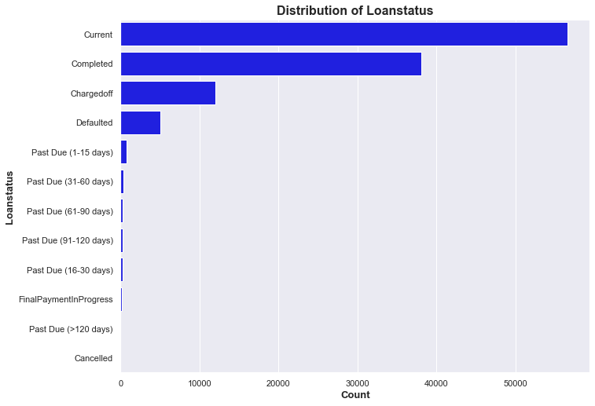

```python
barchart(loan_data_subset, 'LoanStatus')
```

Most of the loans in the data are current/active loans, followed by completed loans

**Borrower APR**

What is the distribution of borrowerAPR?

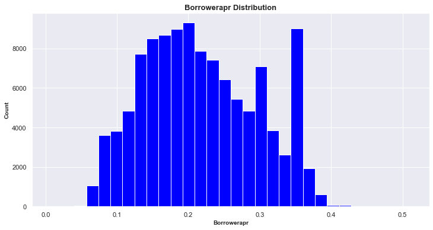

```python
histogram(loan_data_subset, 'BorrowerAPR', 30)
```

The plot shows that the 'BorrowerAPR' is a multimodal plot.

**Distribution of BorrowerRate**

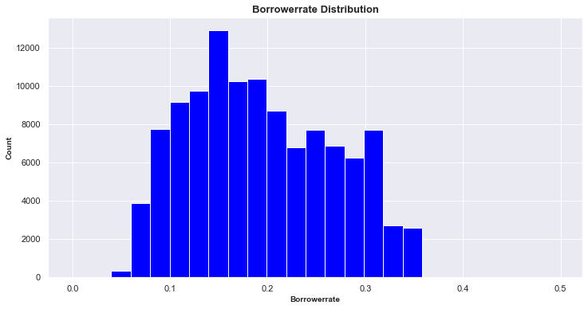

```python
histogram(df=loan_data_subset, col='BorrowerRate', bin_size=25)
```

The borrowerrate has a very similar distribution as the borrowerAPR because the APR is made up of the borrowerrate and other fees.

**ProsperRating Distribution**

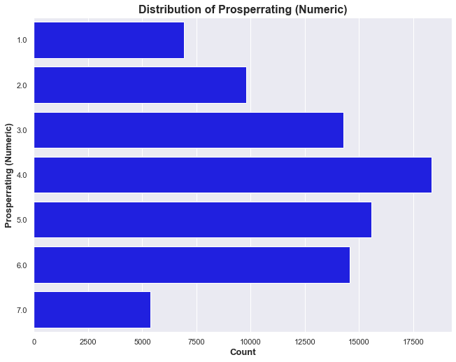

```python
barchart(loan_data_subset, 'ProsperRating (numeric)')
```

The highest rating score (7) is the least popular in the data, which means it's not easily awarded. The most common rating values are the median values (especially 4)

**ProsperScore Distribution**

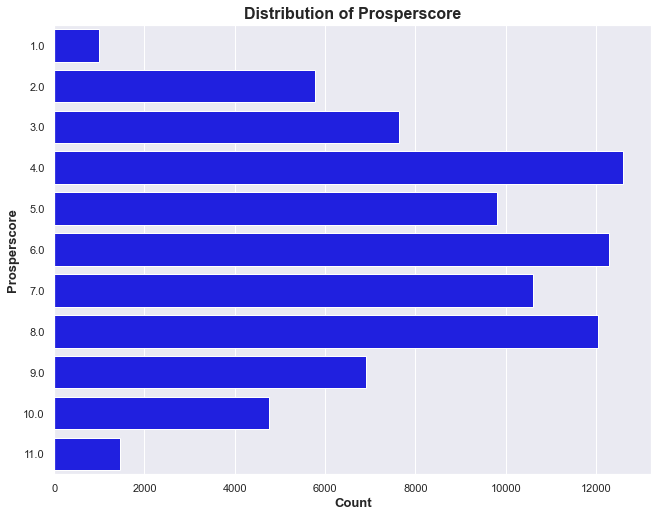

```python
barchart(loan_data_subset, 'ProsperScore')
```

There are different peaks in the prosper score column, mostly on the lower risk side.

**Distribution of Loan Amount**

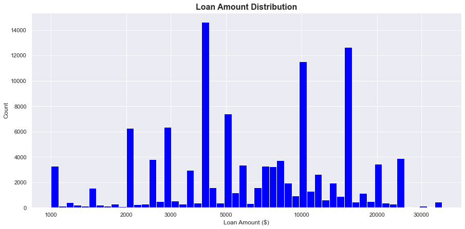

```python
bins = 10 ** np.arange(3, np.log10(loan_data_subset['LoanOriginalAmount'].max())+0.03, 0.03)
plt.figure(figsize = [15, 7])
plt.hist(data = loan_data_subset, x = 'LoanOriginalAmount', bins = bins, color='blue');
ticks = [1000,2000,3000,5000,10000,20000,30000]
labels = ['{}'.format(v) for v in ticks]
plt.xscale('log')
plt.xlabel('Loan Amount ($)')
plt.ylabel('Count')
plt.title('Loan Amount Distribution', fontsize=16, weight='bold')
plt.xticks(ticks, labels);
```

```python
loan_data_subset['LoanOriginalAmount'].max()
```

```
35000
```

```python
loan_data_subset['LoanOriginalAmount'].min()
```

```
1000
```

The amount of loan borrowers apply for/get is very widely distributed from 1000 (lowest) to 35000 (highest)

**Distribution ofsISHomeowner**

```python
loan_data_subset['IsBorrowerHomeowner'].value_counts(normalize=True) * 100
```

```
True     50.447177
False    49.552823
Name: IsBorrowerHomeowner, dtype: float64
```

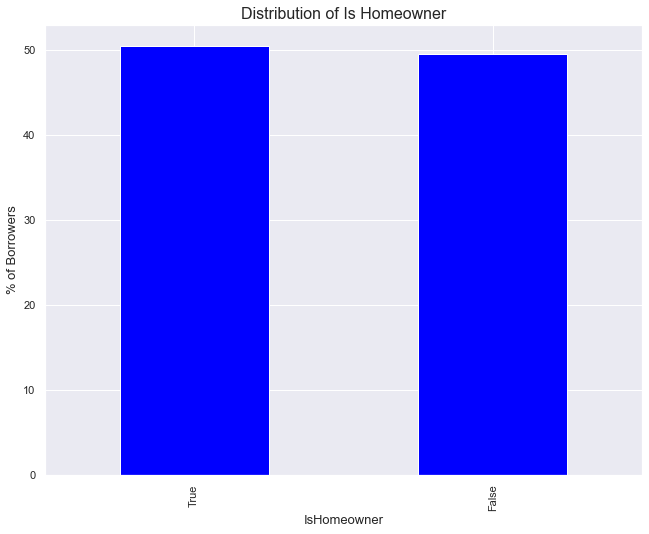

```python
# getting a doughnut plot for the homeowner distribution
(loan_data_subset['IsBorrowerHomeowner'].value_counts(normalize=True) * 100).plot(kind='bar', color='blue')
plt.title('Distribution of Is Homeowner', fontsize=16)
plt.xlabel('IsHomeowner', fontsize=13)
plt.ylabel('% of Borrowers', fontsize=13)
```

The plot above shows an almost even distribution between borrowers who have a home and do not. This means that home ownership is probably not a strong determinant in loan applications.

**Distribution of Occupation**

```python
# top 20 occupations of the borrowers
loan_data_subset['Occupation'].value_counts().head(20)
```

```
Other                                28617
Professional                         13628
Computer Programmer                   4478
Executive                             4311
Teacher                               3759
Administrative Assistant              3688
Analyst                               3602
Sales - Commission                    3446
Accountant/CPA                        3233
Clerical                              3164
Sales - Retail                        2797
Skilled Labor                         2746
Retail Management                     2602
Nurse (RN)                            2489
Construction                          1790
Truck Driver                          1675
Laborer                               1595
Police Officer/Correction Officer     1578
Civil Service                         1457
Engineer - Mechanical                 1406
Name: Occupation, dtype: int64
```

**Distribution of IncomeRange**

```python
loan_data_subset['IncomeRange'].value_counts()
```

```
$25,000-49,999    32192
$50,000-74,999    31050
$100,000+         17337
$75,000-99,999    16916
Not displayed      7741
$1-24,999          7274
Not employed        806
$0                  621
Name: IncomeRange, dtype: int64
```

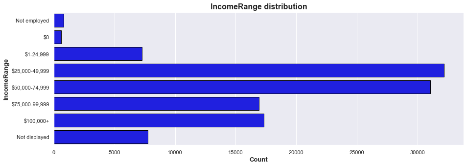

```python
income_order = ['Not employed','$0','$1-24,999','$25,000-49,999','$50,000-74,999','$75,000-99,999','$100,000+','Not displayed']
plt.figure(figsize = [15, 5])
sns.countplot(data = loan_data_subset, y = 'IncomeRange', edgecolor='black',color='blue', order=income_order );
plt.title('IncomeRange distribution',fontsize=16,weight=("bold"))
plt.xlabel('Count',fontsize=13, weight=("bold"))
plt.ylabel('IncomeRange',fontsize=13, weight=("bold"))
```

The income range with the highest number of borrowers is the 25,000-49,999 followed very closely by the 50,000 - 74,999 income bracket

**Employment Status**

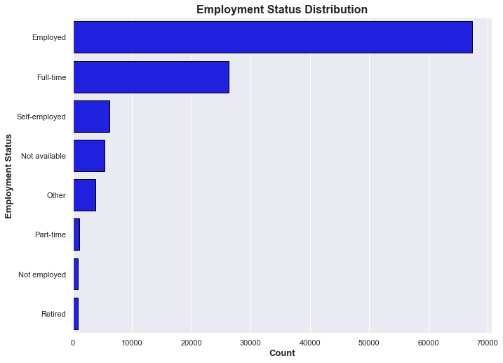

```python
employment_order = loan_data_subset['EmploymentStatus'].value_counts().index
sns.countplot(data = loan_data_subset, y = 'EmploymentStatus', edgecolor='black',color='blue', order=employment_order );
plt.title('Employment Status Distribution',fontsize=16,weight=("bold"))
plt.xlabel('Count',fontsize=13, weight=("bold"))
plt.ylabel('Employment Status',fontsize=13, weight=("bold"))
```

It is easy to see that most of people that applied for loans are employed, and the group with the least number of loans are the retired folks.

## Bivariate Exploration

**Average borrower APR distribution by year**

```python
#convert loan start date to datetime object
loan_data_subset['LoanOriginationDate'] = pd.to_datetime(loan_data_subset['LoanOriginationDate'])
```

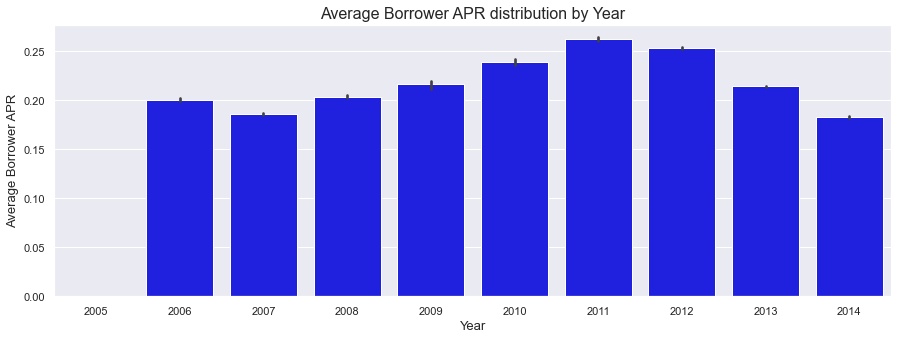

```python
loan_data_subset['year']= loan_data_subset['LoanOriginationDate'].dt.year
plt.figure(figsize = [15, 5])
sns.barplot(data=loan_data_subset, x='year', y='BorrowerAPR', color='blue')
plt.ylabel('Average Borrower APR', fontsize=13)
plt.xlabel('Year', fontsize=13)
plt.title('Average Borrower APR distribution by Year', fontsize=16)
```

**Average borrower APR distribution by Month**

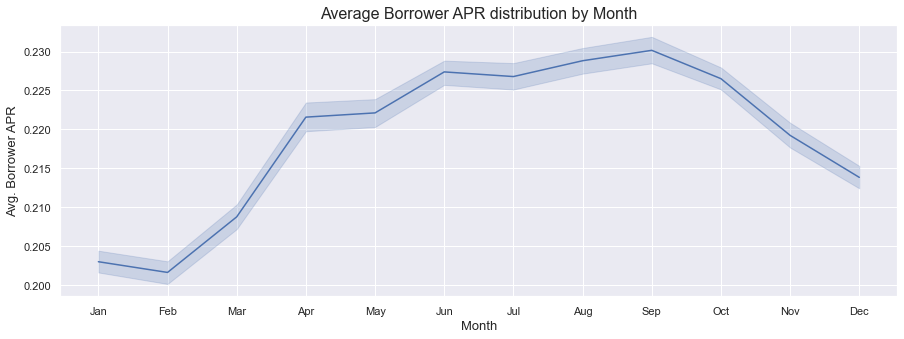

```python
loan_data_subset['month']= loan_data_subset['LoanOriginationDate'].dt.strftime('%b')
month_order=['Jan','Feb','Mar','Apr','May','Jun','Jul','Aug','Sep','Oct','Nov','Dec']
month_order = pd.api.types.CategoricalDtype(ordered=True, categories=month_order)
loan_data_subset['month'] = loan_data_subset['month'].astype(month_order)
plt.figure(figsize = [15, 5])
sns.lineplot(data=loan_data_subset,x='month',y='BorrowerAPR')
plt.ylabel('Avg. Borrower APR', fontsize=13)
plt.xlabel('Month', fontsize=13)
plt.title('Average Borrower APR distribution by Month', fontsize=16)
```

Avg APR is very low in the first quarter of the year, and increases steadily and reaches a peak in September.

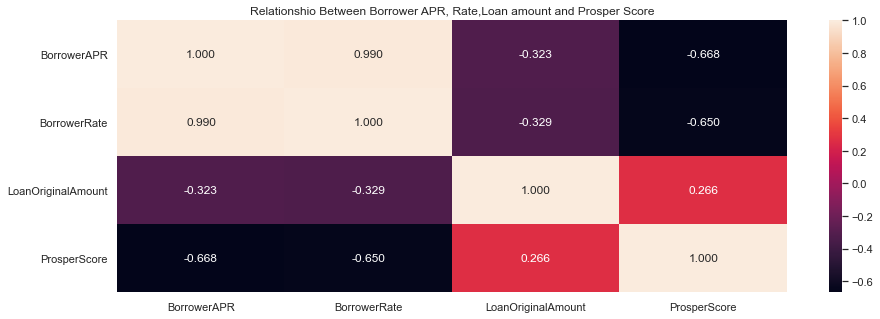

```python
features = ['BorrowerAPR','BorrowerRate','LoanOriginalAmount','ProsperScore']
plt.figure(figsize = [15, 5])
sns.heatmap(loan_data_subset[features].corr(), annot = True, fmt = '.3f')
plt.title('Relationshio Between Borrower APR, Rate,Loan amount and Prosper Score');
```

BorrowerAPR and Borrowerrate are strongly correlated (borrowerAPR is made up of borrowerRate and other fees)

```python
#binning the loan amount into different categories
loan_data_subset['LoanAmount_bin'] = pd.cut(loan_data_subset['LoanOriginalAmount'],
                                            bins=[1000,5000, 10000, 15000, 20000, 25000, 30000, 35000],
                                        labels=['1k-5k','5k-10k','10k-15k','15k-20k','20k-25k','25k-30k','30k-35k'])
```

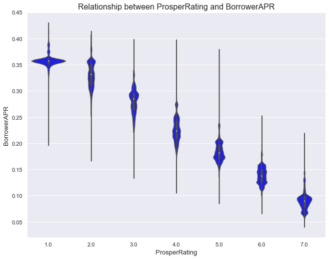

```python
sns.violinplot(data=loan_data_subset, x='ProsperRating (numeric)', y='BorrowerAPR', color='blue');
plt.xlabel('ProsperRating', fontsize=13)
plt.ylabel('BorrowerAPR', fontsize=13)
plt.title('Relationship between ProsperRating and BorrowerAPR', fontsize=16)
```

## Multivariate Exploration

**Effect of Borrower APR on loan amount and Homeownership**

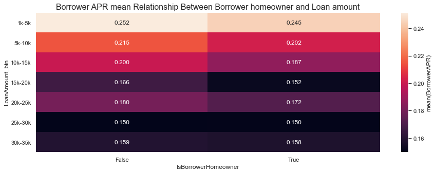

```python
data =loan_data_subset.groupby(['LoanAmount_bin','IsBorrowerHomeowner']).mean()['BorrowerAPR']
data = data.reset_index(name='BorrowerAPR_mean')
data = data.pivot(index = 'LoanAmount_bin', columns = 'IsBorrowerHomeowner', values = 'BorrowerAPR_mean')
plt.figure(figsize = [15, 5])
sns.heatmap(data, annot = True, fmt = '.3f',cbar_kws = {'label' : 'mean(BorrowerAPR)'})
plt.title('Borrower APR mean Relationship Between Borrower homeowner and Loan amount', fontsize=16)
```

BorrowerAPR does not appear to have any effect on home ownership from the heatmap above, on the other hand, loan amount had an inverse relationship with borrower APR.

**Effect of the loan term on the loan and Borrower APR**

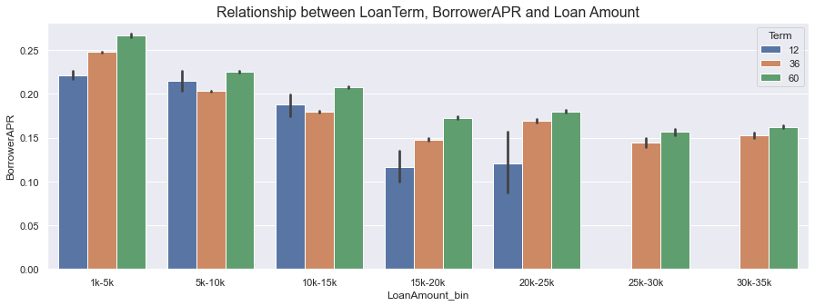

```python
plt.figure(figsize = [15, 5])
fig = sns.barplot(data=loan_data_subset, x='LoanAmount_bin', y='BorrowerAPR', hue='Term')
fig.legend(title = 'Term', loc='upper right')
plt.title("Relationship between LoanTerm, BorrowerAPR and Loan Amount", fontsize=16)
```